# PM566 Midterm

Echo Tang

2022-10-23

## Introduction

Breast cancer is the most common malignant cancer in the world for women with over one million cases being diagnosed annually (Wang 2017). Although mortality rates for breast cancer are lower in the United States and Asia, other countries have unfortunately not seen the same trend, emphasizing the urgency of studying breast cancer and its associated risk factors (Azamjah et al. 2019). Previous studies have shown that race may be a risk factor for breast cancer, as many women of color have higher mortality rates than non-Hispanic white women. Women of color, particularly Black and Native American women, are also associated with getting breast cancer diagnoses at later stages than white women, indicating that there is an association between race and breast cancer diagnosis stage (Ooi et al. 2011). Like other cancers, breast cancer incidence increases with age with women above 50 years old being more likely to develop breast cancer than younger women. On the other hand, however, previous research has demonstrated that those who receive breast cancer diagnoses at younger ages also have higher reported mortality rates than those who are diagnosed later (McGuire et al., 2015). Given that age and race are two risk factors, there is limited research done on how age at diagnosis can *interact* with stage of diagnosis and race specifically in breast cancer diagnosis, and how that in turn can contribute to and exacerbate these differences in mortality rates. Understanding differences between the clinical progression of breast cancer across these risk factors can contribute to more nuanced care that can potentially bridge inequities in survivability.

Given these risk factors, this study aims to address the question if race affects the age of diagnosis for breast cancer, and if the effects of age and diagnosis stage on years survived after diagnosis differ by race. To conduct the analysis, publicly available clinical data from The Cancer Genome Atlas (TCGA) was used, a cancer genomics program that has collected genomics, epigenomics, clinical, transcriptomic, and proteomic data of over 20,000 primary cancer samples across 33 different cancer types (TCGA, n.d.). For this study, only the clinical data for breast cancer patients were accessed to answer the research question. By analyzing the characteristics of breast cancer across multiple different demographics, we hope to gain a more holistic perspective of the disease.

## Methods

Breast cancer clinical data was accessed from TCGA using the R package `TCGAbiolinks` with the accession code “BRCA.” For data wrangling and cleaning, the clinical data was converted to a data table using the `data.table` package.

To prepare the data, missing racial data was imputed based on the most common value. Then, missing numerical data (diagnosis year) was imputed based on mean by sex. Reported substages of cancer diagnosis were standardized to the five stages I through X. Years survived after diagnosis was used as a metric for survivability and was calculated by taking the difference of year of death calculated from the variable days to death (or the current year 2022 for patients who are still alive) and year of cancer diagnosis. Implausible negative values for years survived were subsequently removed from the dataset. After data cleaning and wrangling, the resulting dataset contained the imputed categorical and numerical variables, standardized stage, and years survived after diagnosis for the remaining 1062 breast cancer patients.

Descriptive and summary statistics for variables of interest were generated and tabulated using the R package `dplyr` and standardized using the `kable` function from `knitr`. Data visualization and exploratory data analysis were done through the R package `ggplot`.

## Preliminary Results

```r
library(SummarizedExperiment)
library(TCGAbiolinks)

clin_query = GDCquery(project = "TCGA-BRCA", data.category = "Clinical", file.type = "xml")

# Only use the download line once when downloading data for the first time, as the data is quite large. I commented out the following line after downloading.

# GDCdownload(clin_query)
clinic = GDCprepare_clinic(clin_query, clinical.info = "patient")
```

```r
library(tidyverse)
library(data.table)
```

```r
clinic = as.data.table(clinic)
skimr::skim(clinic$race_list)
```

```r
clinic %>% group_by(race_list) %>% summarise(count = n())
109/(nrow(clinic))
```

There are 109 empty values, which makes up around 9% of the dataset. As this is still under 10% of the data in this column, this is acceptable for imputation; thus, the missing race values were imputed by the most common value (white patients).

```r
clinic$race_list[clinic$race_list == ""] = "WHITE"
```

```r
knitr::kable(clinic %>%
            group_by(race_list) %>%
            summarise(count = n()),
            caption = "Table 1: Distribution of Race Among Breast Cancer Patients",
            col.names = c("Race", "Number of Individuals"))
```

Table 1: Distribution of Race Among Breast Cancer Patients

| Race | Number of Individuals |
| --- | --- |
| AMERICAN INDIAN OR ALASKA NATIVE | 1 |
| ASIAN | 62 |
| BLACK OR AFRICAN AMERICAN | 201 |
| WHITE | 910 |

White patients make up the vast majority of this dataset, followed by Black American patients.

```r
skimr::skim(clinic$age_at_initial_pathologic_diagnosis)
skimr::skim(clinic$year_of_initial_pathologic_diagnosis)
```

Diagnosis year contained missing values as well; this was imputed based on the average within the gender variable.

```r
clinic = clinic[, diag_year_imp := fcoalesce(as.double(year_of_initial_pathologic_diagnosis), mean(year_of_initial_pathologic_diagnosis, na.rm = TRUE)), by = .(gender)]
clinic$diag_year_imp = ceiling(clinic$diag_year_imp)
```

```r
skimr::skim(clinic$diag_year_imp)
```

```r
sum(is.na(clinic$vital_status))
```

```r
clinic$after_diagnosis = ifelse(is.na(clinic$days_to_death), 2022 - clinic$diag_year_imp, ceiling(clinic$days_to_death/365) - clinic$diag_year_imp)

summary(clinic$after_diagnosis)
```

```r
clinic = clinic[clinic$after_diagnosis > 0, ]
```

```r
sum(is.na(clinic$stage_event_pathologic_stage))
```

```r
dim(clinic)
str(clinic)
head(clinic)
tail(clinic)
```

After data wrangling and cleaning, the resulting dataset consists of 1062 observations for 116 variables, of which include newly imputed categorical variables and the years survived after diagnosis variable.

```r
summary(clinic$stage_event_pathologic_stage)
table(clinic$stage_event_pathologic_stage)

summary(clinic$race_list)
table(clinic$race_list)

summary(clinic$age_at_initial_pathologic_diagnosis)

summary(clinic$diag_year_imp)

summary(clinic$after_diagnosis)
```

Summary statistics for variables of interest were subsequently generated. Summary statistics for cancer stage show that stages I, II, and III contain different substages on top of their overarching numerical stage; these were then standardized by numerical stage. Summary statistics for age in years shows that the mean and median ages are very similar both at around 58.5 years of age; the minimum age was 26 years of age, and the oldest patient was 90 years old at the time of diagnosis. Summary statistics for diagnosis year shows that most patients in the late 2000s with the last patient being diagnosed in 2013. Finally, summary statistics for years survived after diagnosis showed that the minimum years survived was 9 years after diagnosis, and the maximum was 34 years after diagnosis.

```r
clinic$stage_event_pathologic_stage = ifelse(clinic$stage_event_pathologic_stage == "Stage I" |
                          clinic$stage_event_pathologic_stage == "Stage IA" |
                          clinic$stage_event_pathologic_stage == "Stage IB", "Stage I",
      ifelse(clinic$stage_event_pathologic_stage == "Stage II" |
                          clinic$stage_event_pathologic_stage == "Stage IIA" |
                          clinic$stage_event_pathologic_stage == "Stage IIB", "Stage II",
      ifelse(clinic$stage_event_pathologic_stage == "Stage III" |
                          clinic$stage_event_pathologic_stage == "Stage IIIA" |
                          clinic$stage_event_pathologic_stage == "Stage IIIB" |
                          clinic$stage_event_pathologic_stage == "Stage IIIC", "Stage III",
      ifelse(clinic$stage_event_pathologic_stage == "Stage IV", "Stage IV", "Stage X"))))
```

```r
stage_stats = clinic %>%
  group_by(stage_event_pathologic_stage) %>%
  count() %>%
  arrange(desc(n))

stage_stats = stage_stats %>% rename("Number of Patients" = "n", "Stage of Diagnosis" = "stage_event_pathologic_stage")
knitr::kable(stage_stats, caption = "Table 2: Distribution of Cancer Stage Among Breast Cancer Patients")
```

Table 2: Distribution of Cancer Stage Among Breast Cancer Patients

| Stage of Diagnosis | Number of Patients |
| --- | --- |
| Stage II | 612 |
| Stage III | 237 |
| Stage I | 184 |
| Stage X | 17 |
| Stage IV | 12 |

Most patients were diagnosed at Stage II with 612 patients being diagnosed at this stage. This is followed by Stage III with 237 patients and Stage I with 184 patients. Stage IV and X diagnoses make up a very small number of diagnoses in this dataset.

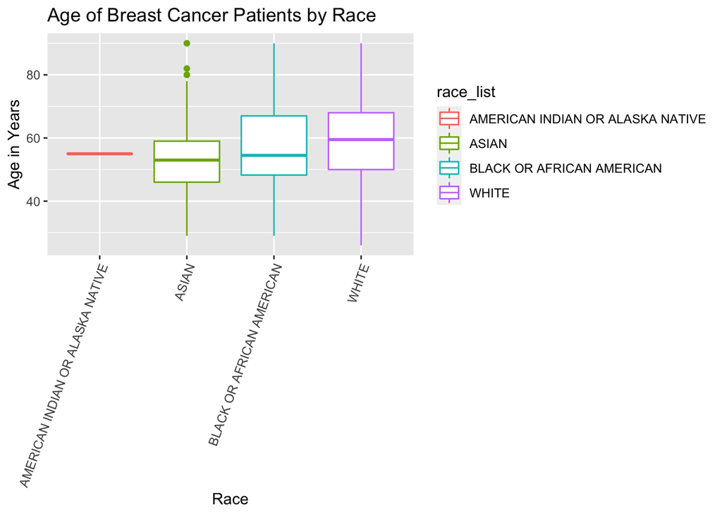

```r
clinic %>%
  ggplot(mapping = aes(x = race_list, y = age_at_initial_pathologic_diagnosis, color = race_list)) +
  geom_boxplot() +
  xlab("Race") +
  ylab("Age in Years") +
  ggtitle("Age of Breast Cancer Patients by Race") + theme(axis.text.x = element_text(angle = 70, vjust = 1, hjust = 1))
```

The distributions for age by cancer stage was then examined.

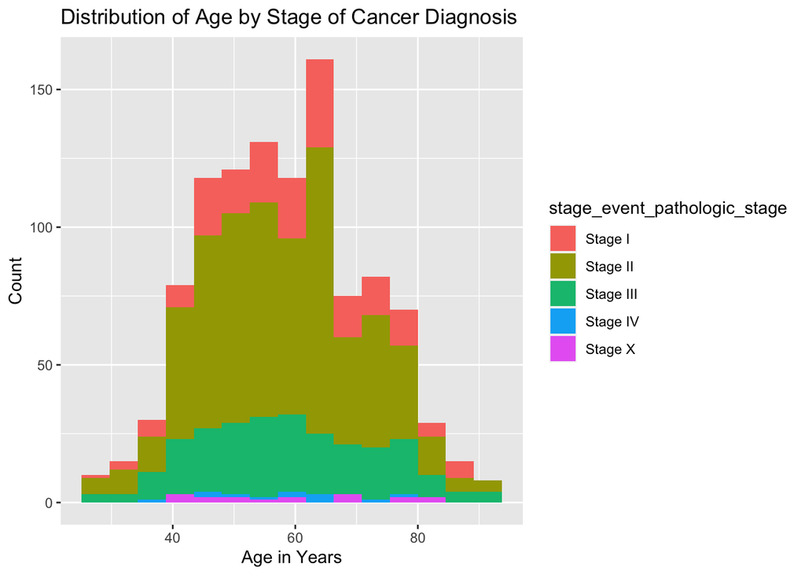

```r
clinic$stage_event_pathologic_stage = as.factor(clinic$stage_event_pathologic_stage)
clinic %>%
  ggplot(mapping = aes(x = age_at_initial_pathologic_diagnosis, fill = stage_event_pathologic_stage)) +
  geom_histogram(bins = 15) +
  xlab("Age in Years") +
  ylab("Count") +
  ggtitle("Distribution of Age by Stage of Cancer Diagnosis")
```

The distributions of age look relatively normal for every cancer stage; from this stacked histogram, the distribution of age doesn’t seem to differ between stage at diagnosis. However, we can also look at the distribution of diagnosis stage by race to see if these distributions are racially differentiated.

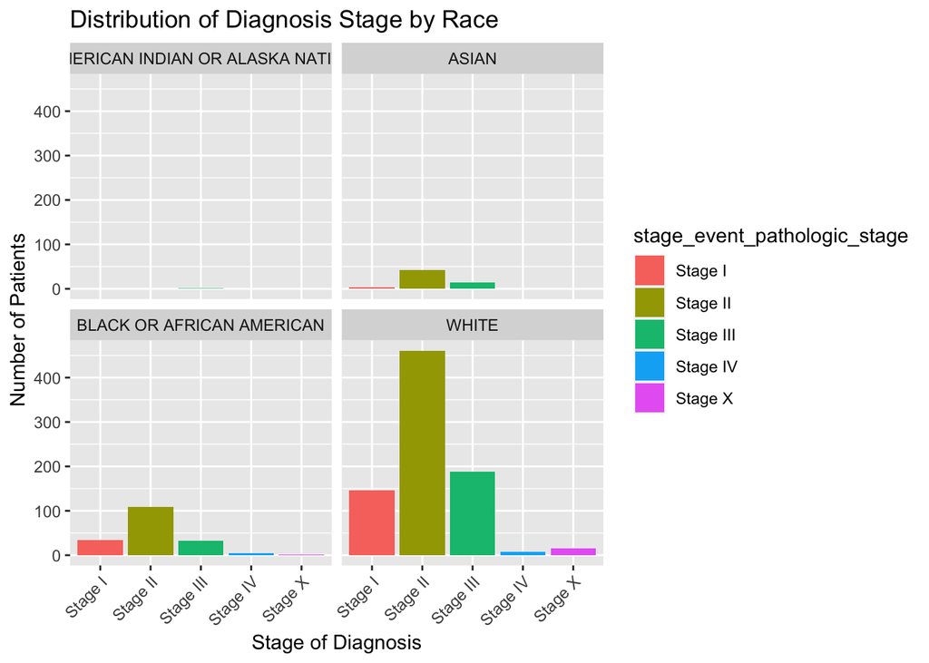

```r
clinic %>%
  ggplot(mapping = aes(x = stage_event_pathologic_stage, fill = stage_event_pathologic_stage)) +
  geom_bar() +
  facet_wrap(~race_list) +
  ggtitle("Distribution of Diagnosis Stage by Race") +
  xlab("Stage of Diagnosis") +
  ylab("Number of Patients") +
  theme(axis.text.x = element_text(angle = 45, vjust = 1, hjust = 1))
```

From these bar graphs, it looks like the distribution of diagnosis stage also does not differ by race. Again, because there was only one Native American patient present in the dataset, there is not enough data to determine if distribution of diagnosis stage differs between Native American patients and patients of other races. Furthermore, there were no patients in stage IV or X among Asian patients; however, the distribution of the remaining stages is consistent with other racial groups.

Then, the relationship between the number of years survived after diagnosis and age of diagnosis per stage of cancer was examined to determine if the relationship between survivability and age differed by stage of diagnosis.

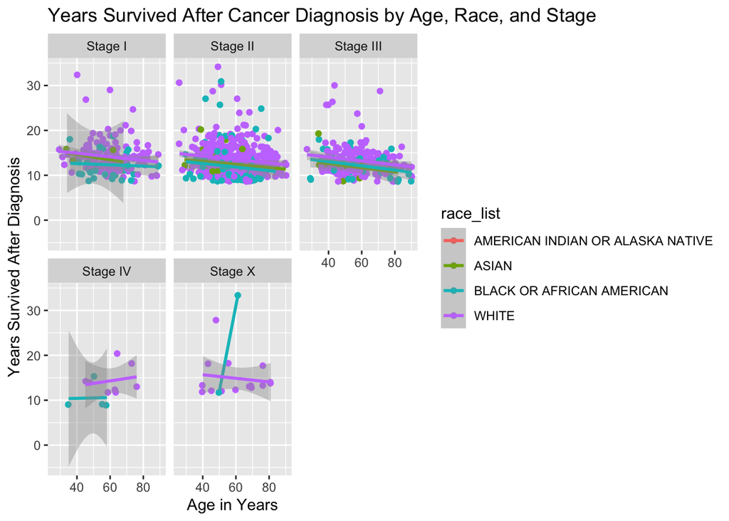

```r
clinic %>%
  ggplot(mapping = aes(x = age_at_initial_pathologic_diagnosis, y = after_diagnosis, color = race_list)) +
  geom_jitter() +
  geom_smooth(method = "lm") +
  facet_wrap(~stage_event_pathologic_stage) +
  xlab("Age in Years") +
  ylab("Years Survived After Diagnosis") +
  ggtitle("Years Survived After Cancer Diagnosis by Age, Race, and Stage")
```

There seems to be very slightly negative relationship between years survived after diagnosis and age in stages I, II, and III across all racial groups.

There is, however, a slight positive relationship between years survived after diagnosis and age for white patients in Stage IV and Black patients in Stage X. This suggests that the relationship between years survived and age does differ to an extent by stage. Among Stage X patients, the relationship between years survived and age of diagnosis for Black patients has a much larger positive magnitude than white patients; this suggests that as a Black patient gets older, their survivability increases. Similarly, for Stage IV white patients, survivability increases as a patient gets older.

The slope for this relationship for white patients is more similar to what was observed in Stages I, II, and III. This suggests that for Stage X cancer patients, the relationship between years survived after diagnosis and age of diagnosis differs by race, particularly among Black patients. However, it is important to note that there are far more patients who were diagnosed in Stages I, II and III compared to Stages IV and X; therefore, a larger sample size would be needed to confirm the relationships for Stages IV and X and how they compare to the other stages.

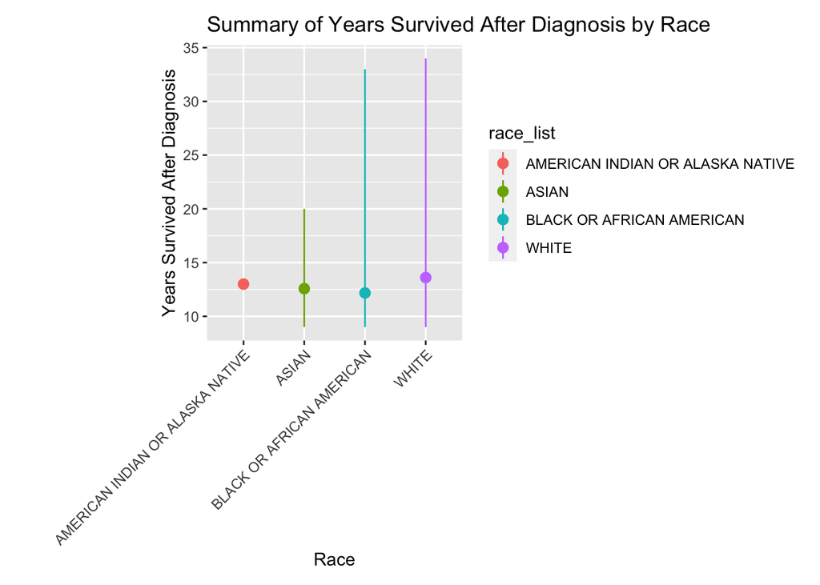

```r
clinic %>%
  ggplot() +
  stat_summary(mapping = aes(x = race_list, y = after_diagnosis, color = race_list),
               fun.min = min, fun.max = max, fun = mean, na.rm = TRUE) +
  xlab("Race") +
  ylab("Years Survived After Diagnosis") +
  ggtitle("Summary of Years Survived After Diagnosis by Race") +
  theme(axis.text.x = element_text(angle = 45, vjust = 1, hjust = 1), plot.margin = margin(10, 10, 10, 100))
```

The summary graph suggests that there is not much difference between years survived after diagnosis per race. However, out of all racial groups, white patients demonstrate the largest range in years survived after diagnosis. Asian patients have the smallest range in years survived after diagnosis. Black patients, despite the large range in years survived, have the lowest average years survived after diagnosis. The lowest mean years survived after diagnosis supports previous research where Black women see higher breast cancer mortality than white women; however, it is important to note that the ranges of survivability for both Black and white patients are very large for this dataset.

## References

Azamjah, N., Soltan-Zadeh, Y., & Zayeri, F. (2019). Global trend of breast cancer mortality rate: A 25-year study. Asian Pacific Journal of Cancer Prevention, 20(7), 2015–2020.

McGuire, A., Brown, J., Malone, C., McLaughlin, R., & Kerin, M. (2015). Effects of age on the detection and management of breast cancer. Cancers, 7(2), 908–929.

National Institute of Health. (n.d.). The Cancer Genome Atlas Program. National Cancer Institute. Retrieved October 18, 2022, from https://www.cancer.gov/about-nci/organization/ccg/research/structural-genomics/tcga

Ooi, S. L., Martinez, M. E., & Li, C. I. (2010). Disparities in breast cancer characteristics and outcomes by Race/Ethnicity. Breast Cancer Research and Treatment, 127(3), 729–738.

Wang, L. (2017). Early Diagnosis of Breast Cancer. Biosensors for Cancer Biomarkers, 17(7), 1572.